# 07_sin_amp_per_mid

## 07_sin_amp_per_mid

#### Question

1. Below, on the $ty$ plane, is a graph of $y=A\sin\left(\frac{2\pi}{P}t\right)+D$ with random parameters $A$, $P$, and $D$.

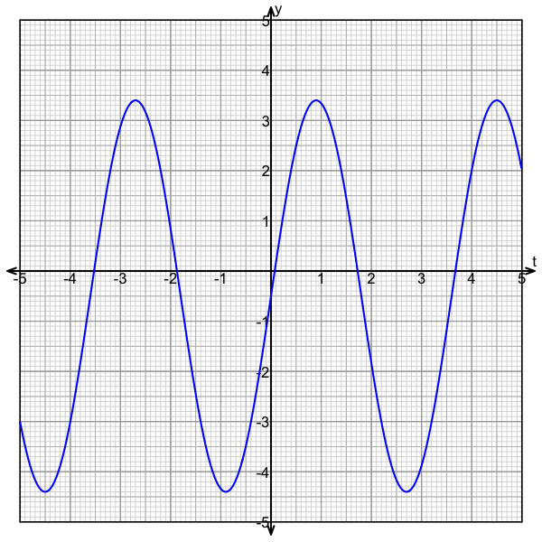

   What are the values of the parameters?
   - $A=$
   - $P=$
   - $D=$

#### Question

2. Below, on the $ty$ plane, is a graph of $y=A\sin\left(\frac{2\pi}{P}t\right)+D$ with random parameters $A$, $P$, and $D$.

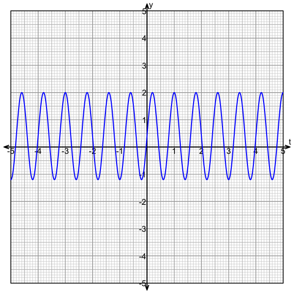

   What are the values of the parameters?
   - $A=$
   - $P=$
   - $D=$

#### Question

3. Below, on the $ty$ plane, is a graph of $y=A\sin\left(\frac{2\pi}{P}t\right)+D$ with random parameters $A$, $P$, and $D$.

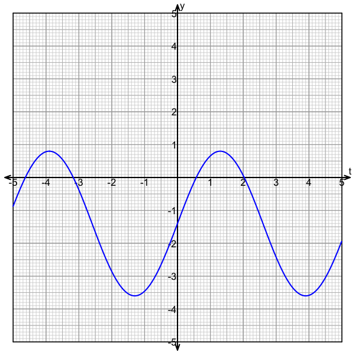

   What are the values of the parameters?
   - $A=$
   - $P=$
   - $D=$

#### Question

4. Below, on the $ty$ plane, is a graph of $y=A\sin\left(\frac{2\pi}{P}t\right)+D$ with random parameters $A$, $P$, and $D$.

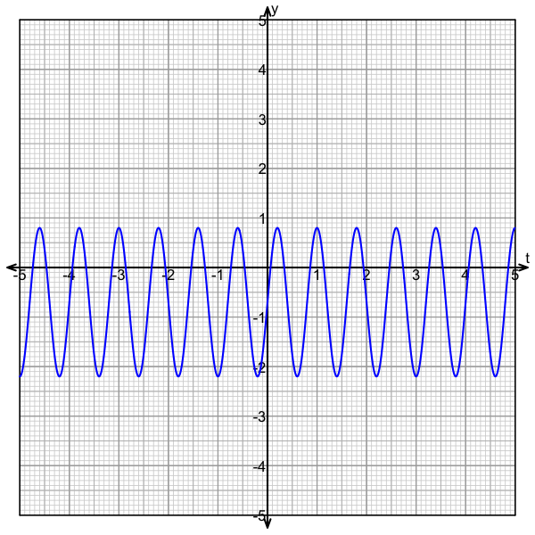

   What are the values of the parameters?
   - $A=$
   - $P=$
   - $D=$

#### Question

5. Below, on the $ty$ plane, is a graph of $y=A\sin\left(\frac{2\pi}{P}t\right)+D$ with random parameters $A$, $P$, and $D$.

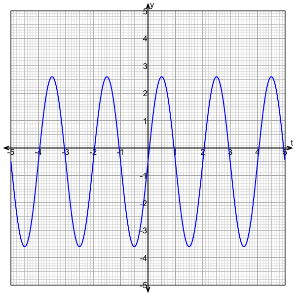

   What are the values of the parameters?
   - $A=$
   - $P=$
   - $D=$

#### Question

6. Below, on the $ty$ plane, is a graph of $y=A\sin\left(\frac{2\pi}{P}t\right)+D$ with random parameters $A$, $P$, and $D$.

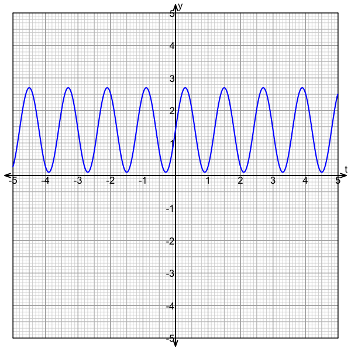

   What are the values of the parameters?
   - $A=$
   - $P=$
   - $D=$

#### Question

7. Below, on the $ty$ plane, is a graph of $y=A\sin\left(\frac{2\pi}{P}t\right)+D$ with random parameters $A$, $P$, and $D$.

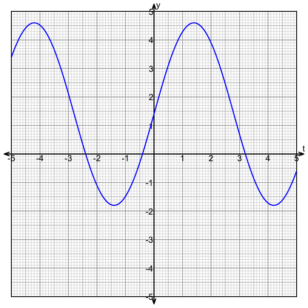

   What are the values of the parameters?
   - $A=$
   - $P=$
   - $D=$

#### Question

8. Below, on the $ty$ plane, is a graph of $y=A\sin\left(\frac{2\pi}{P}t\right)+D$ with random parameters $A$, $P$, and $D$.

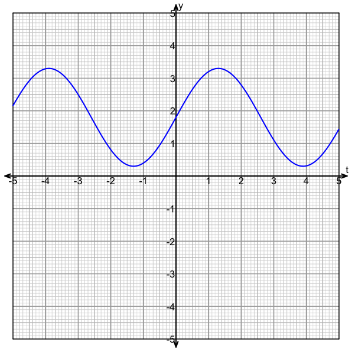

   What are the values of the parameters?
   - $A=$
   - $P=$
   - $D=$